# Python Coding I: Arrays and Image Processing

[figure not shown]

This module will cover the following topics:

- Working with Arrays
- Conditions and loops
- Functions
- Image processing

### Chapter 1: Arrays

#### 1.0: Numpy

```python
#let us import the library that we will be using to work with arrays
import numpy as np
```

#### 1.1: Array Creation

There are various ways we can create an array. Arrays can also have multiple dimensions. In this section, we will explore creation methods in numpy such as arange, array, ones and random.

```python
#use arange function
array_example=np.arange(10,25,5)
print(array_example)
```

```
[10 15 20]
```

```python
#one dimensional array
one_dim=np.array([1,2,3])
print(one_dim)
```

```
[1 2 3]
```

```python
#two dimensional array
two_dim=np.array([[1,2,3],[4,5,6],[7,8,9]])
print(two_dim)
```

```
[[1 2 3]
 [4 5 6]
 [7 8 9]]
```

```python
#three dimensional array
three_dim=np.array([[[1,2,3],[4,5,6],[7,8,9]],[[1,2,3],[4,5,6],[7,8,9]],[[1,2,3],[4,5,6],[7,8,9]]])
print(three_dim)
```

```
[[[1 2 3]
  [4 5 6]
  [7 8 9]]

 [[1 2 3]
  [4 5 6]
  [7 8 9]]

 [[1 2 3]
  [4 5 6]
  [7 8 9]]]
```

```python
#one dimensional array
one_dim_pixel=np.random.randint(0, 255, size=(3))
print(one_dim_pixel)
```

```
[138  22 171]
```

```python
#two dimensional arrays
two_dim_pixel=np.random.randint(0,255,size=(3,3))
print(two_dim_pixel)
```

```
[[ 90 100 104]
 [ 28 184 149]
 [253 187  48]]
```

```python
#three dimensional arrays. This dimension represents most of the images we will be dealing with. 28 pixels by 28 pixels
three_dim_pixel=np.random.randint(0,255,size=(28,28,3))
print(three_dim_pixel)
```

```
[[[213 119 251]
  [163 166 177]
  [159 172 157]
  ...
  [245 253  93]
  [ 56  60 211]
  [ 68  18 181]]

 [[192 207 177]
  [170 230  33]
  [128 203 116]
  ...
  [134 171  39]
  [  8 230 139]
  [252 157 102]]

 [[151  64 254]
  [ 29  67 247]
  [233 226 198]
  ...
  [150 164  33]
  [173 178  64]
  [ 77 144  28]]

 ...

 [[ 99 152 175]
  [ 86  12 202]
  [232  10 154]
  ...
  [201 132  60]
  [ 29 141 185]
  [  2  91 141]]

 [[204 168 109]
  [185 246 233]
  [ 82 107 167]
  ...
  [240 208 225]
  [143 123 137]
  [ 44   6 103]]

 [[169 252 133]
  [218 201 185]
  [ 91 227 217]
  ...
  [ 69 130 159]
  [211 167 160]
  [225 133   8]]]
```

```python
#create an array of ones
array_ones=np.ones((3,4))
print(array_ones.astype(float))
```

```
[[1. 1. 1. 1.]
 [1. 1. 1. 1.]
 [1. 1. 1. 1.]]
```

#### 1.2: Array Info

Now that we have created these arrays, we can start exploring their content and find out more about their types.

```python
#find out array dimensions
print(one_dim_pixel.ndim)
print(two_dim_pixel.ndim)
print(three_dim_pixel.ndim)
```

```
1
2
3
```

```python
#one_dim_pixel.
```

```python
#find out the dimensions
print(three_dim_pixel.shape)
```

```
(28, 28, 3)
```

```python
#find out array size
print(one_dim_pixel.size)
print(two_dim_pixel.size)
print(three_dim_pixel.size)
```

```
3
9
2352
```

```python
#find out how many bytes per item
print(one_dim_pixel.itemsize)
print(two_dim_pixel.itemsize)
print(three_dim_pixel.itemsize)
```

```
8
8
8
```

```python
#find out the total number of bytes
print(one_dim_pixel.nbytes)
print(two_dim_pixel.nbytes)
print(three_dim_pixel.nbytes)
```

```
24
72
18816
```

```python
#find out the sum of the array
print(three_dim_pixel.sum())
```

```
307646
```

```python
#find out the minimum pixel
print(three_dim_pixel.min())
```

```
0
```

```python
#find out the average pixel value
print(three_dim_pixel.mean())
```

```
130.8018707482993
```

```python
#find out the standard deviation of the pixels
print(np.std(three_dim_pixel))
```

```
73.0281305637982
```

```python
#three_dim_pixel.
```

#### 1.3: Slicing an Array

In this section we will learn how to pull individual elements or a range of elements from arrays.

```python
#pull an element from a one dimensional array
one_dim_pixel[1]
```

```
22
```

```python
#pull a range of elements from an array
one_dim_pixel[0:3]
```

[output not shown]

```python
#pull an element from a two dimensional array
two_dim_pixel[1,1]
```

```
184
```

```python
#pull an element from a three dimensional array
three_dim_pixel[:,:,:]
```

```
array([[[213, 119, 251],
        [163, 166, 177],
        [159, 172, 157],
        ...,
        [245, 253,  93],
        [ 56,  60, 211],
        [ 68,  18, 181]],

       [[192, 207, 177],
        [170, 230,  33],
        [128, 203, 116],
        ...,
        [134, 171,  39],
        [  8, 230, 139],
        [252, 157, 102]],

       [[151,  64, 254],
        [ 29,  67, 247],
        [233, 226, 198],
        ...,
        [150, 164,  33],
        [173, 178,  64],
        [ 77, 144,  28]],

       ...,

       [[ 99, 152, 175],
        [ 86,  12, 202],
        [232,  10, 154],
        ...,
        [201, 132,  60],
        [ 29, 141, 185],
        [  2,  91, 141]],

       [[204, 168, 109],
        [185, 246, 233],
        [ 82, 107, 167],
        ...,
        [240, 208, 225],
        [143, 123, 137],
        [ 44,   6, 103]],

       [[169, 252, 133],
        [218, 201, 185],
        [ 91, 227, 217],
        ...,
        [ 69, 130, 159],
        [211, 167, 160],
        [225, 133,   8]]])
```

```python
#use conditions to splice an array
one_dim_pixel_less_150=one_dim_pixel[one_dim_pixel<150]
```

[output not shown]

```python
one_dim_pixel<150
```

```
array([ True,  True, False])
```

```python
one_dim_pixel
```

```
array([138,  22, 171])
```

#### 1.4: Restructuring Arrays

Sometimes in Neural Networks, we will need to flatten an image by converting its multi-dimensional space into one dimension. This can be done with the function reshape.

```python
print(two_dim_pixel)
```

```
[[ 90 100 104]
 [ 28 184 149]
 [253 187  48]]
```

```python
#transpose an array
print(np.transpose(two_dim_pixel))
```

```
[[ 90  28 253]
 [100 184 187]
 [104 149  48]]
```

```python
#resize the array. we are taking the 3x3 dimensional array and flattening it to be 1x9 one dimensional array
np.reshape(two_dim_pixel,(1,9))
```

```
array([[ 90, 100, 104,  28, 184, 149, 253, 187,  48]])
```

#### 1.5: Appending to an Array

```python
#add another pixel
np.append(one_dim_pixel,[150])
#np.delete(one_dim_pixel,2)
#one_dim_pixel
```

[output not shown]

#### 1.6: Displaying an Image Array

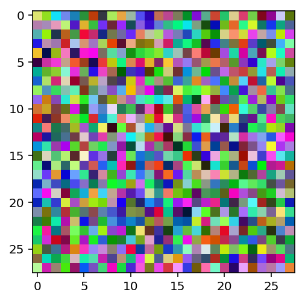

```python
#use the imshow function from matplotlib to display an array as a picture
import matplotlib.pyplot as plt            # visualize images
plt.imshow(three_dim_pixel)
```

## 4.0 Conditions and Loops

Python allows us to assess logical conditions as follows:

- Equals: `a == b`
- Not Equals: `a != b`
- Less than: `a < b`
- Less than or equal to: `a <= b`
- Greater than: `a > b`
- Greater than or equal to: `a >= b`

The output of each of the above logical conditions is `True` or `False`. These conditions can be used in IF statements, For loops, and while loops.

### 4.1 IF Condition

Programming is very useful in turning any decision-making process into an efficient and reproducible process. Decision-making usually involves the following steps:

- Information collection
- Coming up with logic
- Definining actions for each logic

If statements allow us to build code that executes certain actions depending on the values of the information collected. For example, if we want to write a piece of code that decides whether a number is positive, negative or 0, we can construct it the following way (note the indentation):

```python
input=-2                     # information collection

if (input > 0):                   # logic definition
    print('input is positive!')   # action
    #print('something else')
elif(input < 0):                  # alternative logic
    print('input is negative!')   # alternative action
else:                             # if none of the above conditions are met
    print('input is zero!')       # then execute this action
```

```
input is negative!
```

```python
#look at the output of condition
input>0
```

[output not shown]

### 4.2 FOR Loops

Loops provide you with the ability to loop through any list and execute a certain action on each element within that list.

```python
sum_n = 0

for number in np.arange(0,4):
    sum_n = sum_n + number
    print('the number in this iteration is:' + str(number))

print('sum is:' + str(sum_n))
```

```
the number in this iteration is:0
the number in this iteration is:1
the number in this iteration is:2
the number in this iteration is:3
sum is:6
```

## 5.0 Functions

Functions are a great way to combine everything we have learned so far! A function is a block of code that can contain a mix of conditional logic, variable definitions, loops and actions. The intention of a functions is to take in a number of input variables and return actions/decisions. Each function is usually developed to perform a specific task. Functions can then come together to produce a pipeline.

Let's start with a simple function that simply takes your name and prints a personalized greeting!

```python
def my_function(name_input):                            # here you define your function name. notice the indentation
  print("Hello " + name_input + "! How are you today?") # actions that your function is suppose to perform
```

```python
my_function('Fouad')                                    # you can call your function. try changing what you pass to it
```

```
Hello Fouad! How are you today?
```

Let's write a function that calculates the average score from a list of scores that get passed to it:

```python
# let's first define our function
def calculate_average(x):  # give it a unique name
    total = sum(x)         # find the sum
    length = len(x)        # find the number of numbers
    average = total/length # calculate the average
    return(average)        # return the average
```

```python
calculate_average([1,2,3])                                    # you can call your function. try changing what you pass to it
```

```
2.0
```

This function actually exists in Python and it is called mean(). Let's try running it and see if we get the same results.

```python
from statistics import mean
print(mean([1,2,3]))
```

```
2
```

## 6.0 Image Processing

In this section, you will learn how to load and process images using Python. This will be useful when we perform image classification using neural networks! There are many packages that we can use to do this. We will utilize Keras (a package that we will use to perform machine learning) to do some of these tasks. The aim of this exercise is to get you familiar with:

- Loading an image
- Converting an image to an array of pixels
- Understand RGB
- Write a function that identifies R2D2 vs Darth Vader

#### 6.1: Load Required Libraries

You will only need 3 libraries to perform the above tasks!

```python
import matplotlib.pyplot as plt            # visualize array of pixels
from keras.preprocessing import image      # preprocess images
from PIL import ImageOps                   # preprocess images
```

#### 6.2 Load R2D2 and Darth Vader Images

Using the **load_img** function from **image** library, let's try to load the image r2d2.png and darth.png. The function has multiple paramteres:

- path= we use this parameter to specify the location of the image
- color_mode= we can pick gray scale
- target_size= we can specify the dimensions

```python
r2d2 = image.load_img(path="/home/user/data/r2d2.png",target_size=(180,180))
darth = image.load_img(path="/home/user/data/darth.png",target_size=(180,180))
```

[figure not shown]

```python
#view the images
r2d2
```

[figure not shown]

```python
darth
```

#### 6.3 Flipping an Image

[figure not shown]

```python
ImageOps.flip(darth)
```

#### 6.3 Inverting an Image

[figure not shown]

```python
darth_inverted=ImageOps.invert(darth)
darth_inverted
```

#### 6.3 Convert to an array of pixels

Now that we have loaded the images. Let us convert them to an array of pixels using the **img_to_array** function from **image** library

```python
r2d2_arr = image.img_to_array(r2d2)
darth_arr = image.img_to_array(darth)
```

```python
#what does an array look like? it looks very similar to the one we created earlier
r2d2_arr.shape
```

```
(180, 180, 3)
```

```python
r2d2_arr
```

```
array([[[255., 255., 255.],
        [255., 255., 255.],
        [255., 255., 255.],
        ...,
        [255., 255., 255.],
        [255., 255., 255.],
        [255., 255., 255.]],

       [[255., 255., 255.],
        [255., 255., 255.],
        [255., 255., 255.],
        ...,
        [255., 255., 255.],
        [255., 255., 255.],
        [255., 255., 255.]],

       [[255., 255., 255.],
        [255., 255., 255.],
        [255., 255., 255.],
        ...,
        [255., 255., 255.],
        [255., 255., 255.],
        [255., 255., 255.]],

       ...,

       [[255., 255., 255.],
        [255., 255., 255.],
        [255., 255., 255.],
        ...,
        [255., 255., 255.],
        [255., 255., 255.],
        [255., 255., 255.]],

       [[255., 255., 255.],
        [255., 255., 255.],
        [255., 255., 255.],
        ...,
        [255., 255., 255.],
        [255., 255., 255.],
        [255., 255., 255.]],

       [[255., 255., 255.],
        [255., 255., 255.],
        [255., 255., 255.],
        ...,
        [255., 255., 255.],
        [255., 255., 255.],
        [255., 255., 255.]]], dtype=float32)
```

What do the above numbers represent? Visit https://www.rapidtables.com/web/color/RGB_Color.html to find out!

```python
#let us view the first row of pixels
r2d2_arr[1,1:10,]
```

```
array([[255., 255., 255.],
       [255., 255., 255.],
       [255., 255., 255.],
       [255., 255., 255.],
       [255., 255., 255.],
       [255., 255., 255.],
       [255., 255., 255.],
       [255., 255., 255.],
       [255., 255., 255.]], dtype=float32)
```

[figure not shown]

```python
#what row of pixels do you think will have the blue?
r2d2
```

```python
r2d2_arr[7,110,]
```

```
array([255., 255., 255.], dtype=float32)
```

[figure not shown]

```python
#what row of pixels in darth vader's picture will be black?
darth
```

[output not shown]

```python
#can we find the maximum pixel value?
darth_arr.max()
darth_arr.min()
darth_arr.mean()
```

```
133.92812
```

#### 6.4 Build an R2D2 and Darth Vader Classifier

Based on the two pictures you have seen above. What kind of logic do you think we can use to figure out if it is a picture of R2d2 vs Darth Vader. Use the Python skills you have learned so far to write a function that:

- Accepts a picture
- Uses logic to distinguish between darth and r2d2 images
- Returns a message saying if it is darth vader or r2d2

```python
def star_wars(x):
    if (x.mean()<200):
        print('darth')
    else:
        print('r2d2')
    return()
```

```python
star_wars(darth_arr)
```

```
darth
```

```
()
```

```python
star_wars(r2d2_arr)
```

```
r2d2
```

```
()
```

```python
# now that our function is defined, let's try calling it and passing it a pic
star_wars(darth_arr)
```

[output not shown]

```python
#let's try it on a new image!
unknown = image.load_img(path="/home/user/data/unknown.png",target_size=(180,180))
unknown_arr = image.img_to_array(unknown)
star_wars(unknown_arr)
```

```
darth
```

```
()
```

[figure not shown]

```python
#let's see if we got it right
unknown
```

```python
#let's try it on another image!
unknown2 = image.load_img(path="/home/user/data/unknown2.jpg",target_size=(180,180))
unknown2_arr = image.img_to_array(unknown2)
star_wars(unknown2_arr)
```

```
r2d2
```

```
()
```

[figure not shown]

```python
#let's check if we got it right
unknown2
```

```python
#let's try it on another image!
unknown3 = image.load_img(path="/home/user/data/unknown3.jpeg",target_size=(180,180))
unknown3_arr = image.img_to_array(unknown3)
star_wars(unknown3_arr)
```

[output not shown]

[figure not shown]

```python
unknown3
```

Why do you think it did not get the above right? What have we not considered?

[figure not shown]

2019